# Презентация лабораторной работы

Лабораторная работа №2

Швецов Михаил Романович

1132236100@rudn.ru

Российский университет дружбы народов

2026-09-02

# Информация

## Докладчик

- **Швецов Михаил Романович**
- студент кафедры теории вероятностей и кибербезопасности
- Российский университет дружбы народов им. П. Лумумбы
- 1132236100@rudn.ru
- https://DarkkLord.github.io/ru/

[figure not shown]

# Выполнение лабораторной работы

Создаём рабочий каталог и активируем проект (рис. 1).

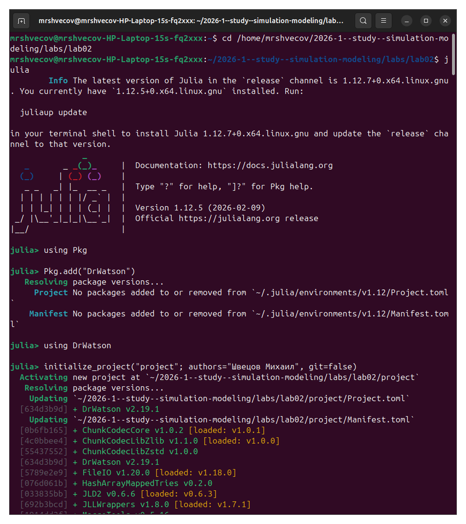

Рисунок 1: Каталог и активация проекта:

Далее устанавливаем необходимые пакеты (рис. 2).

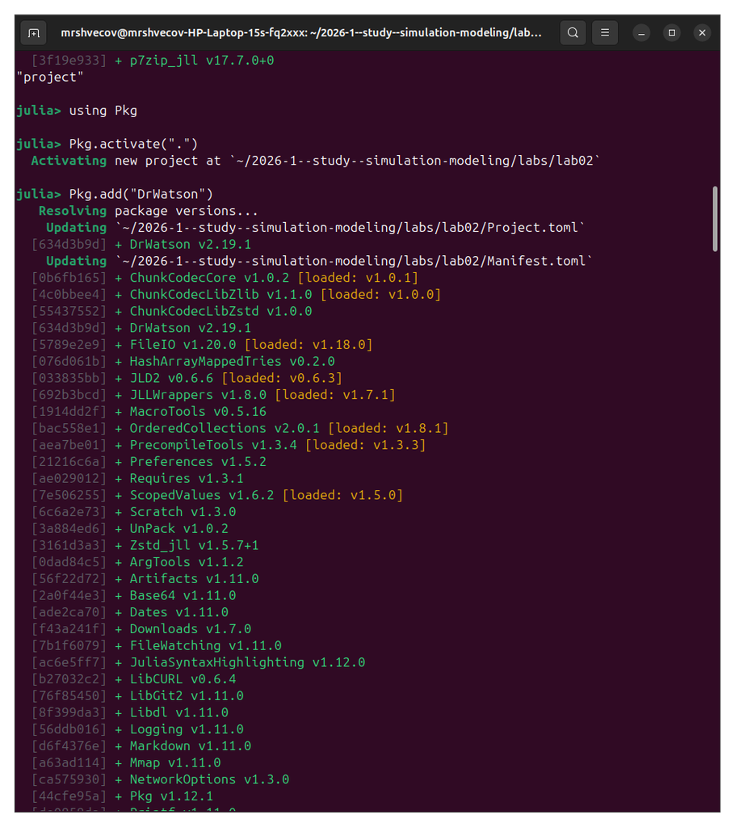

Рисунок 2: Установка пакетов:

Далее проверяем правильность установки (рис. 3).

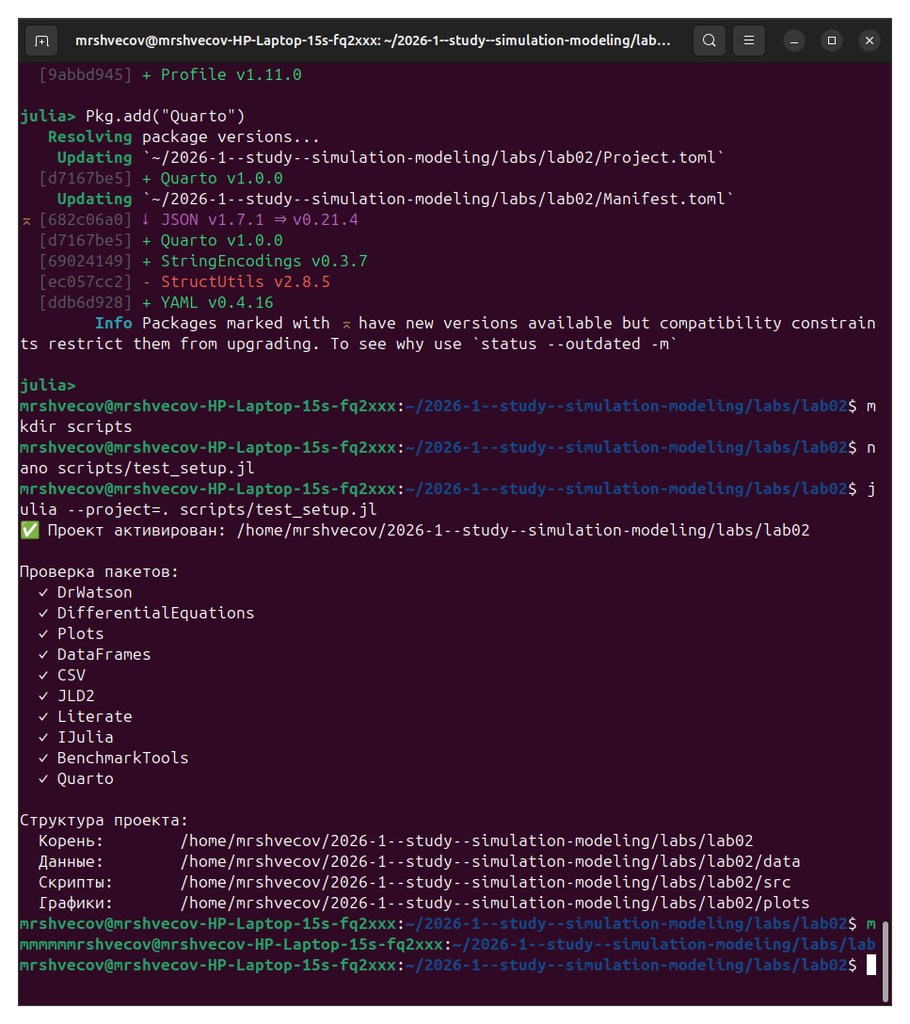

Рисунок 3: Проверка - успешно:

Далее мы смотрим какие пакеты нужно доустановить для наших скриптов и устанавливаем их (рис. 4).

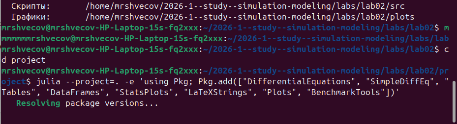

Рисунок 4: Установка:

Установка дополнительного пакета для второго скрипта (рис. 5).

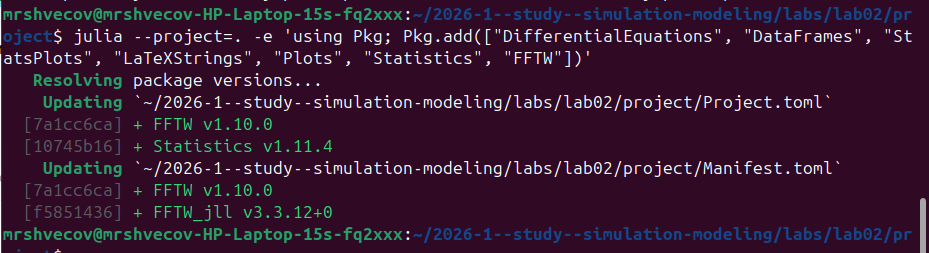

Рисунок 5: Установка:

Создадим и запустим первый скрипт (рис. 6).

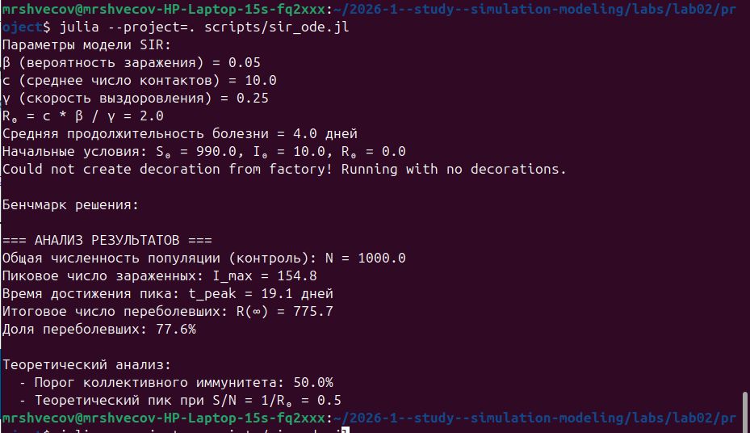

Рисунок 6: Запуск первого скрипта:

Создаём и запускаем второй скрипт (рис. 7).

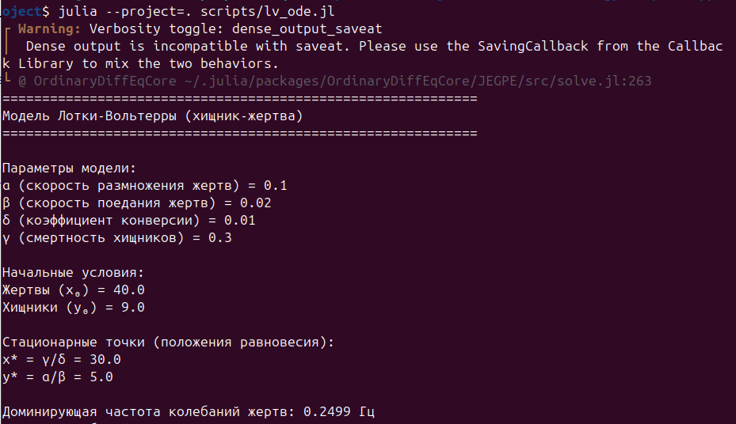

Рисунок 7: Запуск второго скрипта:

Загружаем пакет Literate (рис. 8).

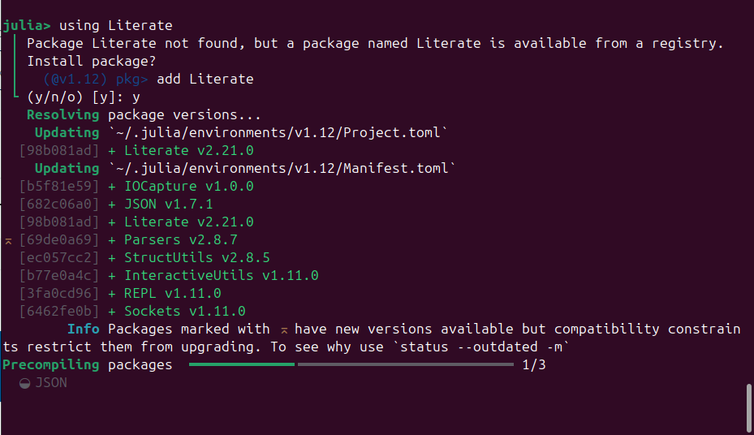

Рисунок 8: Загрузка:

Создадим литературный стиль маркдаун для первого скрипта (рис. 9).

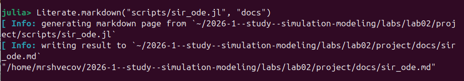

Рисунок 9: Маркдаун для первого скрипта:

Создадим литературный стиль notebooks для первого скрипта (рис. 10).

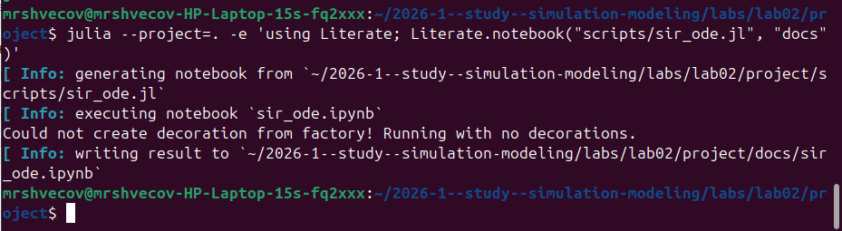

Рисунок 10: Notebooks для первого скрипта:

Создадим литературный стиль маркдаун для второго скрипта (рис. 11).

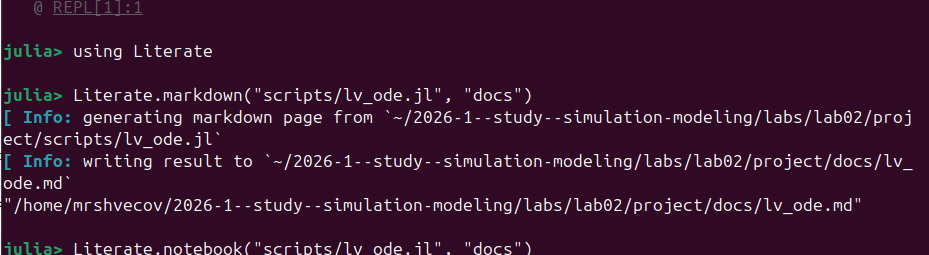

Рисунок 11: Маркдаун для второго скрипта:

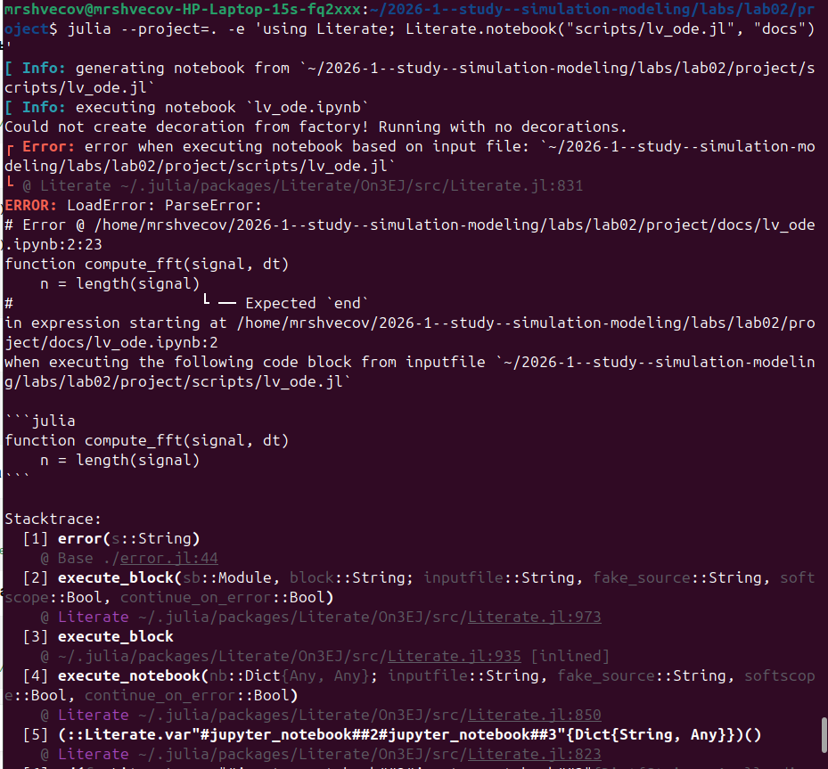

[figure not shown]

Рисунок 13: Проверка:

Далее мы добавили в код в литературном стиле вычисление для набора параметров и снова создаём литературный стиль маркдаун(рис. 14).

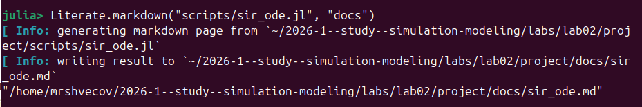

Рисунок 14: Создание маркдаун для скрипта с набором параметров:

Создадим notebooks для скрипта с набором параметров (рис. 15).

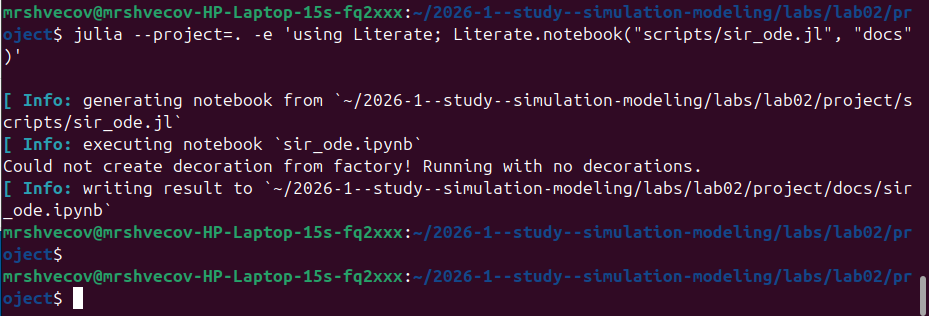

Рисунок 15: Notebooks для скрипта с набором параметров:

Создаём документацию в _quarto для обоих скриптов (рис. 16).

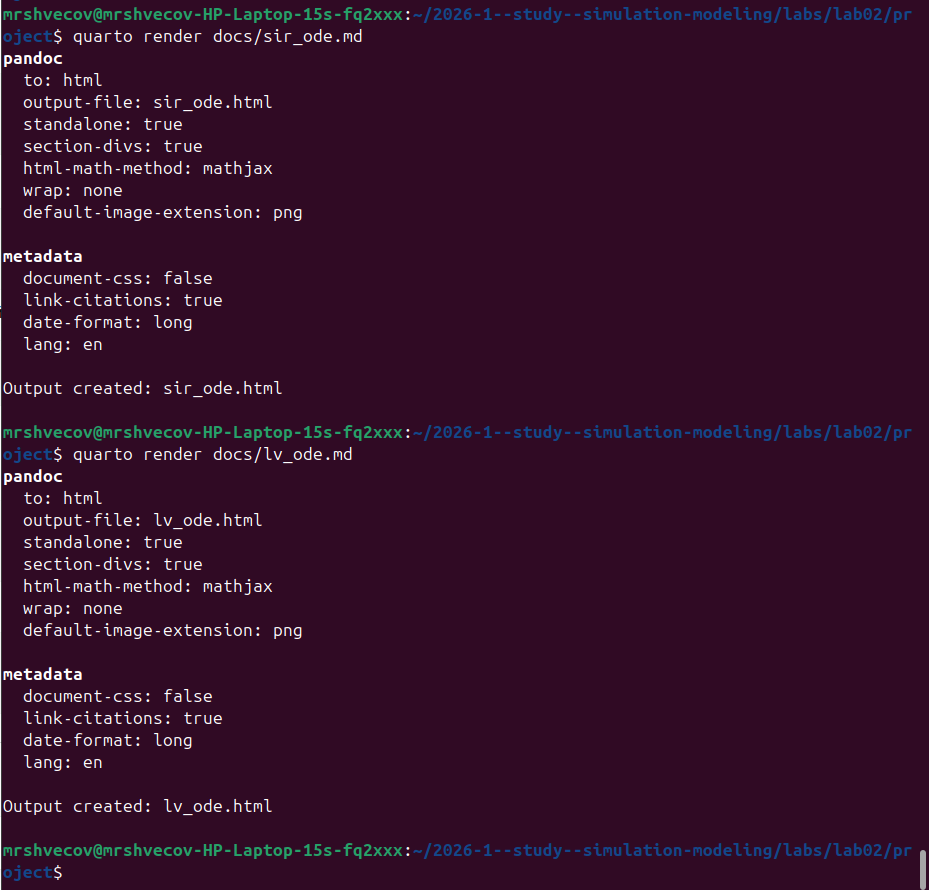

Рисунок 16: документация _quarto для обоих парпметров:

Удостоверимся, что документы созданы (рис. 17).

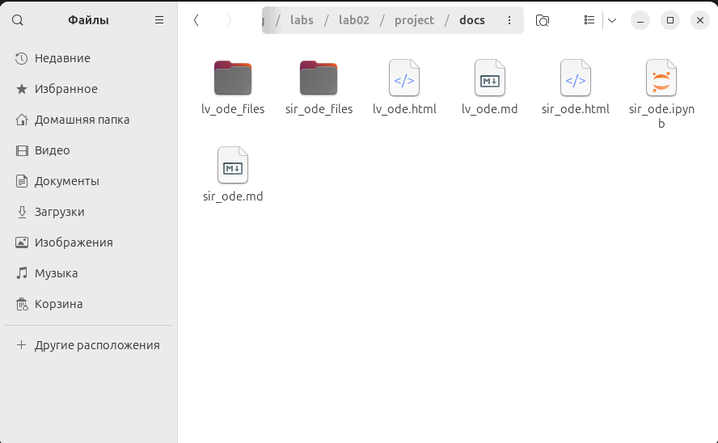

Рисунок 17: Проверка:

# Выводы

В данной лабораторной работе мы создали два скрипта, преобразовали их в литературный стиль, добавили набор параметров и создали документацию в формате _quarto.